# Week 5: Intro to Bayesian Inference

PS 818 - Data Analysis with Statistical Models

Anton Strezhnev

strezhnev@wisc.edu

University of Wisconsin-Madison

October 5, 2026

## Intro to Bayesian Inference

## Previously

- **Wrapping up MLE**
  - **Latent variables** and discrete choice: ordinal logit, multinomial logit, and the conditional logit
  - **Duration models**: modelling the hazard, censoring, and the Cox proportional hazards model
  - Estimated via Maximum Likelihood
    - $\theta$ is a fixed, unknown constant
    - Uncertainty comes from **repeated sampling** - the *sampling distribution* of $\hat{\theta}$

## This week

- **Bayesian inference**
  - What if we treat $\theta$ as having **uncertainty**
  - We want the **posterior** distribution conditioning on our observed data $\theta | \mathbf{Y}$
  - But Bayes’ rule tells us that the likelihood is only half of this.
    - We also need a **prior** on $\theta$.
- **Defining a Bayesian Model**
  - Writing down the data-generating process
  - “Plate notation” for concise model summaries

## Intro to Bayesian Inference

## Bayesian inference

- In the **frequentist** paradigm, we took a particular approach to thinking about *randomness* when trying to learn about an unknown parameter $\theta$ using observed data $\mathbf{Y}$
  - $\theta$ is an unknown **constant**
  - $\mathbf{Y}$ are random variables
  - $\hat{\theta}$ is our estimator of $\theta$ - it’s a function of random variables
  - Probabilities reflect behavior in *repeated samples*
- **Bayesian** inference takes a different approach to the problem. Rather than treating $\theta$ as a constant, we consider it to be **random** as well!
  - Probabilities reflect **beliefs** about a particular quantity
  - $f(\theta)$ denotes our *prior* beliefs about the value of $\theta$
  - $f(\theta | \mathbf{Y})$ is the *posterior* distribution given the observed data. This is our target of inference
  - $\mathbf{Y}$ are still random variables…but the posterior distribution *conditions* on them
- We derive the posterior using **Bayes rule**

  $$f(\theta | \mathbf{Y}) = \frac{f(\mathbf{Y} | \theta)}{f(\mathbf{Y})} f(\theta)$$

## Bayesian inference

- The denominator can be written as an integral over all of the possible values of $\theta$ (marginalizing over $\theta$)

  $$f(\mathbf{Y}) = \int f(\mathbf{Y},\theta)d\theta = \int f(\mathbf{Y}|\theta)f(\theta)d\theta$$
- So often we’ll write the posterior distribution *up to a proportionality constant* as

  $$\underbrace{f(\theta | \mathbf{Y})}_{\text{posterior}} \propto \underbrace{f(\mathbf{Y} | \theta)}_{\text{likelihood}} \times \underbrace{f(\theta)}_{\text{prior}}$$

## Bayesian inference

- In addition to the posterior distribution of the parameters $\theta$, we’ll often want to generate “forecasts” of an out-of-sample $\tilde{Y}$ conditional on what we have observed
  - This involves integrating over the posterior values of the parameter $\theta$

  $$\begin{align*}f(\tilde{Y}|\mathbf{Y}) &= \int f(\tilde{Y}, \theta | \mathbf{Y}) d\theta\\
  &= \int f(\tilde{Y}| \theta, \mathbf{Y}) f(\theta | \mathbf{Y}) d\theta\\
  &= \int f(\tilde{Y}| \theta) f(\theta | \mathbf{Y}) d\theta\end{align*}$$

## Bayesian inference

- We also might reason about two different values of $\theta$: $\{\theta_1, \theta_2\}$ and their relative odds. This has a nice expression in terms of the *prior* times a *likelihood ratio*

  $$\frac{f(\theta_1|\mathbf{Y})}{f(\theta_2|\mathbf{Y})} = \frac{f(\theta_1)}{f(\theta_2)} \times \frac{f(\mathbf{Y}|\theta_1)}{f(\mathbf{Y}|\theta_2)}$$
- Inference on the posterior is often referred to as **updating** the prior and often can be conceptualized in terms of *sequential* changes to our beliefs about the parameter.
- Suppose we have two samples $\mathbf{Y}_1$ and $\mathbf{Y}_2$. Our posterior can be written as:

  $$\begin{align*}f(\theta | \mathbf{Y}_1, \mathbf{Y}_2) &\propto f(\mathbf{Y}_2, \mathbf{Y}_1 | \theta) \times f(\theta) \\ &\propto f(\mathbf{Y}_2 | \mathbf{Y}_1, \theta) \times f(\mathbf{Y}_1 | \theta) \times f(\theta) \\ &\propto f(\mathbf{Y}_2 | \mathbf{Y}_1, \theta) \times f(\theta | \mathbf{Y}_1) \end{align*}$$
- The posterior becomes the new “prior”!

## Application: Absentee Ballot Rejection

- A voter who returns an absentee ballot can still have it **rejected**
  - In Wisconsin, these decisions are made by **municipal clerks**
  - This has been the subject of some controversy when municipalities are **overly strict**
  - Reporting suggests that since 2024, officials in the city of Mequon have been using a particularly strict standard for adjudicating witness addresses (Shur 2026).
  - Let’s see if that is detectable in the **data**!
- The EAC’s *Election Administration and Voting Survey* (EAVS) reports how many mail ballots were returned and rejected in every election jurisdiction (U.S. Election Assistance Commission 2025)
- For each municipality $i$, $i \in \{1, 2, \dotsc, N\}$, we observe (November 2024 general election):
  - $Y_i$: The number of returned absentee ballots that were rejected for **discretionary** reasons (i.e. not because the ballot arrived late or the voter died)
  - $n_i$: The number of absentee ballots returned on time by living voters

## Application: Absentee Ballot Rejection

- We’ll start with a simple model
  - Assume $Y_i$ is a draw from a binomial distribution with a total number of trials $n_i$ and “rejection” probability $\pi_i$.
  - $\pi_i$ comes from a **Beta** distribution with *hyperparameters* $\alpha_0$ and $\beta_0$

  $$Y_i \sim \text{Binomial}(n_i, \pi_i)$$
  $$\pi_i \sim \text{Beta}(\alpha_0, \beta_0)$$

## Plate notation

- A common method of writing statistical models is via **plate notation**
  - These encode independence and dependence assumptions across parameters and data.

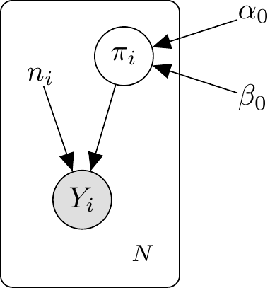

## Features of a Bayesian model

- There are four types of variables in a Bayesian model
  - **Observed Data**: Variables that have a probability distribution but on whose observed values we condition - $Y_i$
  - **Known Constants**: Fixed quantities that do not have probability distributions (e.g. regressors or other features of the nodes) - $n_i$, $N$, $\alpha_0$, $\beta_0$
  - **Deterministic quantities**: Transformations of other variables
  - **Latent parameters**: Variables that have a probability distribution that we do not observe - $\pi_i$

## Features of a Bayesian model

- Sometimes the known constants are *actually* known by us (e.g. $N$ or $n_i$) and in other cases they are *assumed to be known*
  - These are typically parameters of the prior distribution which are called **hyperparameters** (here: $\alpha_0$ and $\beta_0$)
  - The hyperparameters govern the distribution of the prior
- In Bayesian inference, we are interested in either obtaining the **posterior** of the latent parameters *or* integrating them out (in the latter case, they are sometimes referred to as “nuisance” parameters)
  - Here, we want to obtain $f(\pi_i | \mathbf{Y})$
  - When writing the posterior, we’ll often omit the implicit conditioning on the observed constants.

## The Likelihood

- Remember the posterior distribution is proportional to the **likelihood** times the **prior**

  $$\underbrace{f(\pi_i | \mathbf{Y})}_{\text{posterior}} \propto \underbrace{f(\mathbf{Y} | \pi_i)}_{\text{likelihood}} \times \underbrace{f(\pi_i)}_{\text{prior}}$$
- First, let’s derive the **likelihood** $f(\mathbf{Y} | \pi_i)$
- Since the $Y_i$ are independent conditional on $\pi_i$, we can write:

  $$f(\mathbf{Y} | \pi_i) = \prod_{j=1}^N f(Y_j | \pi_i)$$
- Next, for $j \neq i$, we have $f(Y_j | \pi_i) = f(Y_j)$ since $Y_j$ only depends on $\pi_j$. That’s just a constant term and drops out of the posterior distribution, leaving

  $$f(\pi_i | \mathbf{Y}) = f(\pi_i | Y_i) \propto f(Y_i | \pi_i) f(\pi_i)$$

## The Likelihood and Prior

- What’s $f(Y_i | \pi_i)$? We’ve defined it as the binomial PMF

  $$f(Y_i | \pi_i) = {n_i \choose Y_i} \pi_i^{Y_i}(1- \pi_i)^{n_i - Y_i}$$
- What about the prior? $f(\pi_i)$? We’ve chosen the **beta** distribution

  $$f(\pi_i) = \frac{\Gamma(\alpha_{0} + \beta_{0})}{\Gamma(\alpha_0)\Gamma(\beta_0)} \pi_i^{\alpha_0 - 1}(1- \pi_i)^{\beta_0 - 1}$$
- The Beta distribution has some notable features.
  - Its mean: $E[\pi_i] = \frac{\alpha_0}{\alpha_0 + \beta_0}$
  - Its variance $Var(\pi_i) = \frac{\alpha_0\beta_0}{(\alpha_0 + \beta_0)^2(\alpha_0 + \beta_0 + 1)}$

## The Beta Distribution

- Let’s see how the parameters influence the shape of the beta. $\text{Beta}(2,2)$:

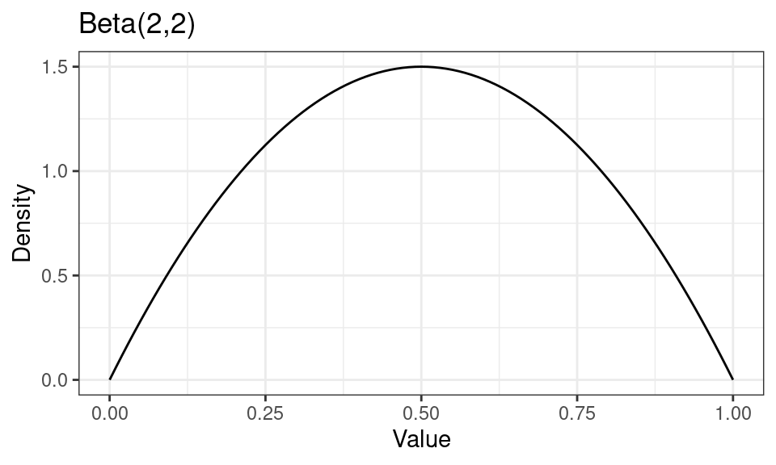

## The Beta Distribution

- $\text{Beta}(100,200)$:

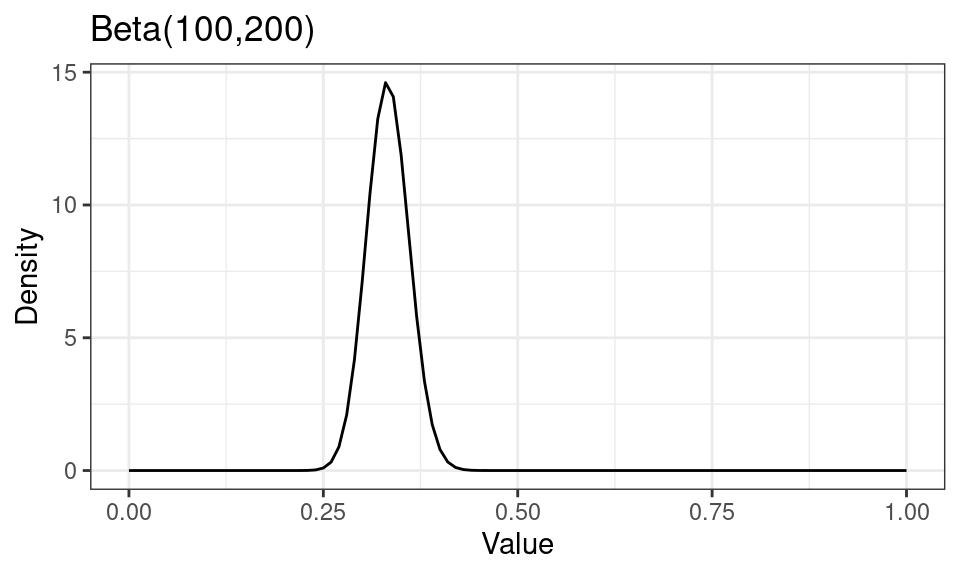

## Choosing a prior

- There are two ways to think about choosing a prior distribution
  - **Informative** prior - Use the prior to encode our existing beliefs about the parameter
  - **Uninformative/Diffuse** prior - Pick a prior that will have the least impact on the posterior distribution
- We also need to consider the *shape* of the prior distribution $f(\pi_i)$
  - Why did we pick the Beta distribution?
  - Because it has a special property when combined with a binomial likelihood.
  - It is a **conjugate** prior to the binomial likelihood.
- **Conjugate prior**: A prior distribution is *conjugate* to a particular likelihood if the posterior distribution is of the same form as the prior
  - $f(\theta)$ is beta; $f(\mathbf{Y} | \theta)$ is binomial; $f(\theta | \mathbf{Y})$ is beta

## Choosing a prior

- In this case, $\pi_i$ must be between $0$ and $1$, so we already have some information.
- One possible choice for an *uninformative* prior is the uniform distribution - each parameter value is equally likely:
  $$f(\pi_i) \propto 1$$
  - In settings where the parameter takes on values $(-\infty, \infty)$, we could still consider a “uniform” prior but it will be **improper** as it’s not a density that integrates to $1$
- For $\pi_i \in (0, 1)$, the uniform prior corresponds to the $\text{Beta}(1,1)$ distribution
  - Originally proposed by Bayes.

## Choosing a prior

- Haldane proposed instead $\text{Beta}(0,0)$ - notably this is *improper* $\pi_i^{-1}(1-\pi_i)^{-1}$

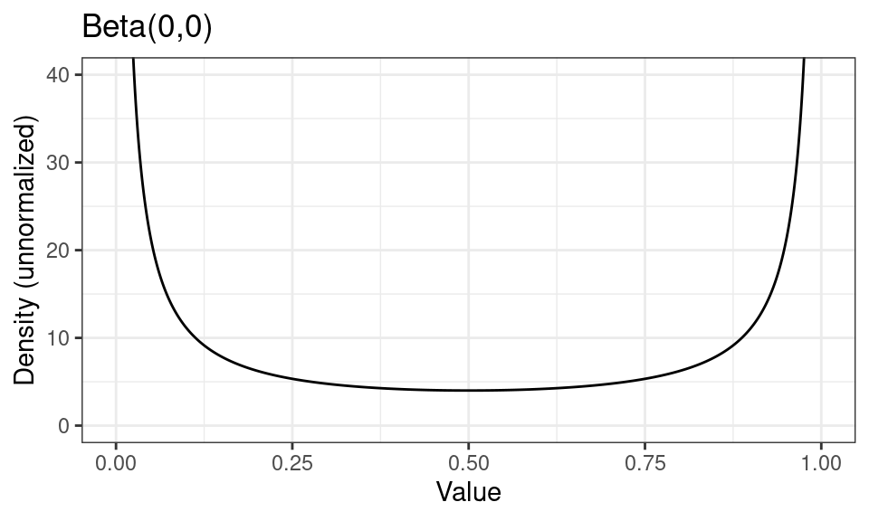

## Choosing a prior

- And Jeffreys proposed $\text{Beta}(.5, .5)$

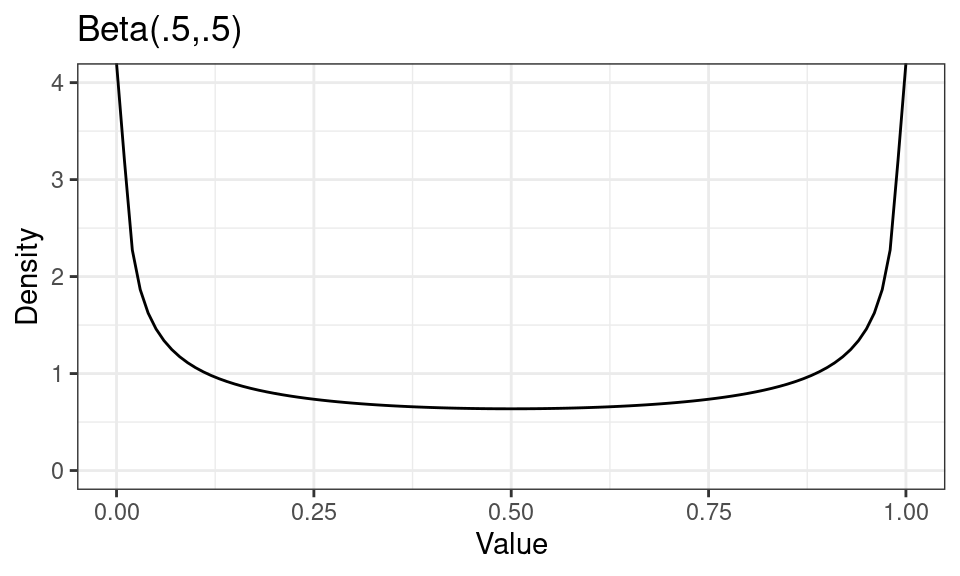

## The posterior density

- We’ve mentioned that $f(\pi_i | Y_i)$ is a beta distribution – let’s show that!

  $$f(\pi_i | \mathbf{Y}) \propto f(Y_i | \pi_i) f(\pi_i)$$
- Plug in the densities (we’ll drop any multiplicative constants that don’t depend on $\pi_i$)

  $$f(\pi_i | \mathbf{Y}) \propto \left[\pi_i^{Y_i}(1- \pi_i)^{n_i - Y_i}\right]\times\left[\pi_i^{\alpha_0 - 1}(1- \pi_i)^{\beta_0 - 1}\right]$$
- Adding the exponents

  $$f(\pi_i | \mathbf{Y}) \propto \pi_i^{Y_i + \alpha_0 - 1}(1- \pi_i)^{n_i - Y_i + \beta_0 - 1}$$
- And we can recognize this as the **kernel** of the beta distribution with parameters
  - $\alpha = Y_i + \alpha_0$
  - $\beta = n_i - Y_i + \beta_0$

## Quantities of interest

- Once we have a posterior distribution, we typically will report **summaries**
- **Point** summaries
  - *Posterior Mean*: $\hat{\theta} = E[\theta | \mathbf{Y}]$
  - *Posterior Mode*: $\hat{\theta} = \argmax_{\theta} f(\theta | \mathbf{Y})$
- **Credible interval**: A $95\%$ credible interval $(l_{95}, h_{95})$ is a range of values that contains $95\%$ of the posterior probability

  $$\int_{l_{95}}^{h_{95}} f(\theta | \mathbf{Y})d\theta = .95$$
- There is no one unique credible interval! As a result, there are a few common choices for how to construct a credible interval
  - **Highest Density** interval (HDI) - no values outside of the interval have higher density than values *inside* the interval
  - **Equal-tailed** interval (ETI) - the probability of being below the lower limit is equal to the probability above the upper limit

## Application

- Let’s take a look at the EAVS data for Wisconsin. Start by loading it in (see `data/README.md` for the details)

```r
# EAVS 2024, Wisconsin municipalities (C1b = mail ballots returned by voters, C9a = mail ballots rejected,
# C9b = rejected because late, C9m = rejected because the voter died)
wi <- read_csv("data/eavs_2024_wi.csv")
wi <- wi %>% mutate(n = C1b - C9b - C9m, y = C9a - C9b - C9m) %>% # Discretionary rejections only
  filter(n > 0) %>% # Drop municipalities where no absentee ballots were returned
  transmute(FIPSCode, municipality = Jurisdiction_Name, n, y, mle = y/n)
head(wi)
```

```
# A tibble: 6 × 5
  FIPSCode municipality                               n     y    mle
  <chr>    <chr>                                  <dbl> <dbl>  <dbl>
1 00100    CITY OF ABBOTSFORD - MULTIPLE COUNTIES    59     0 0
2 00175    TOWN OF ABRAMS - OCONTO COUNTY           185     0 0
3 00225    TOWN OF ACKLEY - LANGLADE COUNTY          30     2 0.0667
4 00275    CITY OF ADAMS - ADAMS COUNTY              70     0 0
5 00300    TOWN OF ADAMS - ADAMS COUNTY             127     0 0
6 00325    TOWN OF ADAMS - GREEN COUNTY              30     0 0
```

- The statewide rejection rate

```r
state_rate <- sum(wi$y)/sum(wi$n)
state_rate
```

```
[1] 0.00208
```

## Application

- Our baseline approach – just take the mean everywhere. Which municipalities reject the most ballots?

```r
wi %>% arrange(desc(mle)) %>% select(municipality, n, y, mle) %>% head(5)
```

```
# A tibble: 5 × 4
  municipality                            n     y   mle
  <chr>                               <dbl> <dbl> <dbl>
1 TOWN OF ALVIN - FOREST COUNTY           4     2 0.5
2 VILLAGE OF LOWELL - DODGE COUNTY       18     3 0.167
3 TOWN OF VANCE CREEK - BARRON COUNTY     7     1 0.143
4 TOWN OF RIETBROCK - MARATHON COUNTY    29     4 0.138
5 TOWN OF PERSHING - TAYLOR COUNTY       15     2 0.133
```

- All tiny towns!
- And at the other end, 79% of municipalities have a rejection rate of *exactly* zero.

## Application

- The most extreme rejection rates come from the municipalities with the fewest ballots

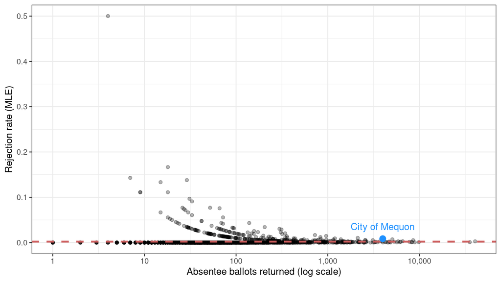

## Application

- Consider the “worst” municipality in the state: the **Town of Alvin** in Forest County

```r
alvin <- wi %>% filter(municipality == "TOWN OF ALVIN - FOREST COUNTY")
alvin
```

```
# A tibble: 1 × 5
  FIPSCode municipality                      n     y   mle
  <chr>    <chr>                         <dbl> <dbl> <dbl>
1 01625    TOWN OF ALVIN - FOREST COUNTY     4     2   0.5
```

- 2 of 4 returned ballots were rejected
  - Do we *really* believe that the Town of Alvin rejects 50% of its absentee ballots?

## Application

- Let’s get the posterior distribution for $\pi_i$ for the Town of Alvin under an uninformative uniform prior

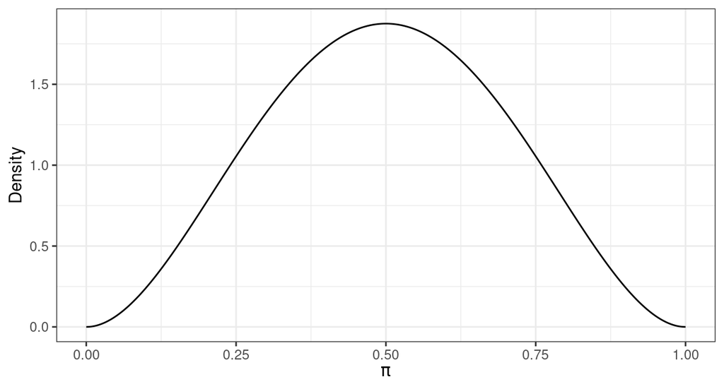

```r
posterior_alpha <- alvin$y + 1
posterior_beta <- alvin$n - alvin$y + 1
# Plot the posterior
alv_posterior <- ggplot() + xlim(0, 1)  + geom_function(fun=dbeta, args=list(shape1=posterior_alpha, shape2=posterior_beta), n=1001) + theme_bw() + xlab(expression(pi)) +
  ylab("Density")
alv_posterior
```

## Application

- We know the form of the beta mean, so our posterior mean estimate is

```r
posterior_mean <- posterior_alpha/(posterior_alpha + posterior_beta)
posterior_mean
```

```
[1] 0.5
```

- And we can obtain an equal-tailed 95% credible interval simply via the quantile function

```r
posterior_ci <- c(qbeta(.025, shape1=posterior_alpha, shape2=posterior_beta), qbeta(.975, shape1=posterior_alpha, shape2=posterior_beta))
posterior_ci
```

```
[1] 0.147 0.853
```

## Application

- But we have a lot more information from the other 1846 municipalities in the state

```r
others_rate <- wi %>% filter(municipality != alvin$municipality) %>% summarize(rate = sum(y)/sum(n)) %>% pull(rate)
others_rate
```

```
[1] 0.00208
```

- Our posterior mean under the uniform prior (0.5) is about 240 times the rate in the rest of the state!
  - The “uninformative” prior isn’t actually uninformative
  - It expects that municipalities reject **half** of all ballots!
- What if we instead constructed our prior such that its mean was centered on the rejection rate in the rest of the state?

## Application

- We can interpret the hyperparameters as “previously observed” counts
  - $\frac{\alpha_0}{\alpha_0 + \beta_0}$ is the prior mean – set it to the rejection rate in the rest of the state
  - $\alpha_0 + \beta_0$ controls the strength of the prior – set it to $500$: the prior is “worth” 500 ballots

```r
prior_mean <- others_rate
prior_strength <- 500
# Convert these to alpha/beta
prior_alpha <- prior_mean*prior_strength
prior_beta <- (1 - prior_mean)*prior_strength
c(prior_alpha, prior_beta)
```

```
[1]   1.04 498.96
```

## Application

- Let’s plug-in the new prior parameters

```r
posterior2_alpha <- alvin$y + prior_alpha
posterior2_beta <- alvin$n - alvin$y + prior_beta
# Plot the posterior (cutting off the y-axis - the new posterior is much more concentrated)
alv_posterior2 <- ggplot() + xlim(0, 1)  +  geom_function(fun=dbeta, args=list(shape1=posterior_alpha, shape2=posterior_beta), n=1001, lty=2, lwd=1.5, col="dodgerblue") +
  theme_bw() + xlab(expression(pi)) +
  ylab("Density") + geom_vline(xintercept=prior_mean, lty=2, lwd=1.5, col="indianred") +
  geom_function(fun=dbeta, args=list(shape1=posterior2_alpha, shape2=posterior2_beta), n=1001,lwd=1.5) +
  coord_cartesian(ylim=c(0, 10))
```

## Application

- Uniform prior posterior (blue, dashed), prior mean (red, dashed), and statewide prior posterior (black)

```r
alv_posterior2
```

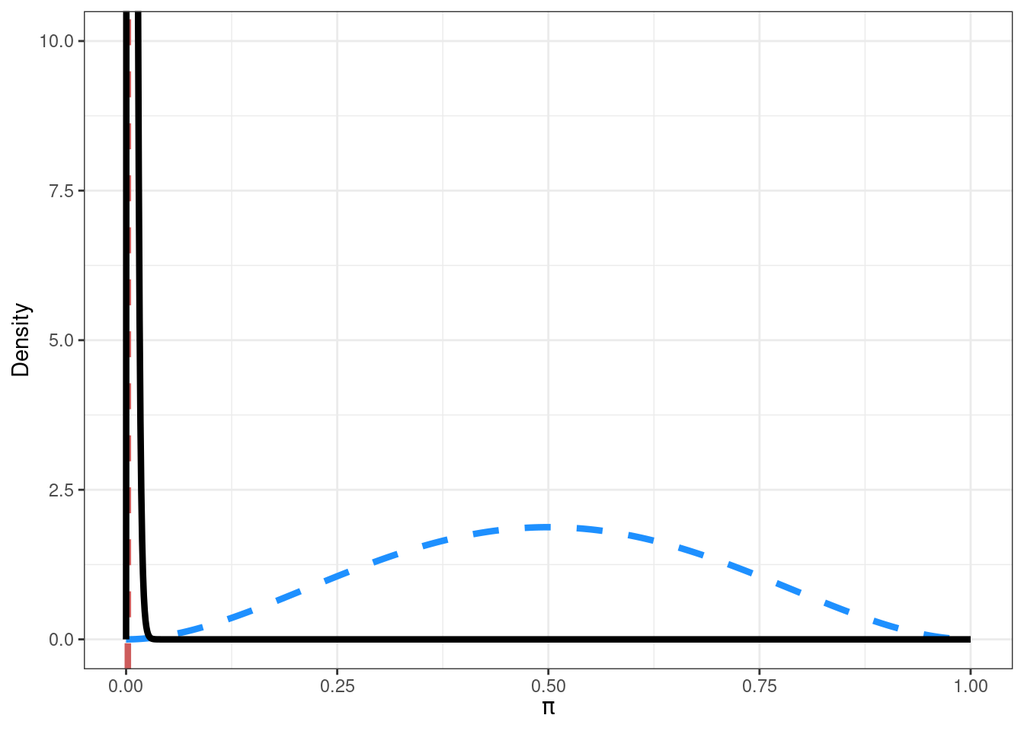

## Application

- Our new posterior mean

```r
posterior2_mean <- posterior2_alpha/(posterior2_alpha + posterior2_beta)
posterior2_mean
```

```
[1] 0.00603
```

- And 95% credible interval

```r
posterior2_ci <- c(qbeta(.025, shape1=posterior2_alpha, shape2=posterior2_beta), qbeta(.975, shape1=posterior2_alpha, shape2=posterior2_beta))
posterior2_ci
```

```
[1] 0.00127 0.01442
```

- With only 4 ballots, the prior dominates. Alvin’s posterior mean is much closer to the statewide rate than to the MLE: 50%.

## Application

- Let’s do this for every municipality: pull each estimate toward the statewide rate

```r
wi <- wi %>% mutate(post_mean = (y + prior_strength*state_rate)/(n + prior_strength))
```

- Now who rejects the most ballots?

```r
wi %>% arrange(desc(post_mean)) %>% select(municipality, n, y, mle, post_mean) %>% head(5)
```

```
# A tibble: 5 × 5
  municipality                          n     y    mle post_mean
  <chr>                             <dbl> <dbl>  <dbl>     <dbl>
1 TOWN OF DOVER - RACINE COUNTY       297     9 0.0303    0.0126
2 TOWN OF UNION - EAU CLAIRE COUNTY   313     9 0.0288    0.0124
3 TOWN OF CHETEK - BARRON COUNTY      205     7 0.0341    0.0114
4 CITY OF PARK FALLS - PRICE COUNTY   139     6 0.0432    0.0110
5 TOWN OF ALMA - JACKSON COUNTY        66     5 0.0758    0.0107
```

- The top of the list now includes places with more ballots – a high rate on a lot of ballots is more convincing than 2 out of 4

## Application

- The MLE vs. the posterior mean for every municipality (note the different y-axes)

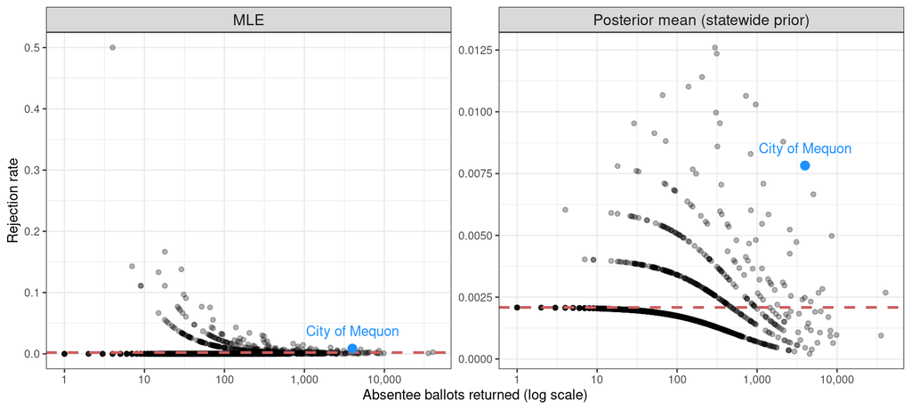

- Small municipalities get pulled almost all the way to the statewide rate while big cities barely move.

## Does pooling help?

- How do we know whether this is a good idea? We also have EAVS data from the November 2022 election (U.S. Election Assistance Commission 2023)
  - Use each municipality’s 2024 data to predict its 2022 rejections
  - The prior only matters when there’s very little data, so focus on the municipalities with fewer than 200 returned ballots in 2024

```r
wi_2022 <- read_csv("data/eavs_2022_wi.csv") %>%
  mutate(n_2022 = C1b - C9b - C9m, y_2022 = C9a - C9b - C9m) %>% filter(n_2022 > 0) %>% # Discretionary rejections only
  transmute(FIPSCode, n_2022, y_2022)
oos <- wi %>% filter(n < 200) %>% inner_join(wi_2022, by="FIPSCode") # Municipalities in both years
scale_2022 <- (sum(wi_2022$y_2022)/sum(wi_2022$n_2022))/state_rate # Statewide 2022 rate relative to 2024
nrow(oos)
```

```
[1] 1418
```

## Does pooling help?

- Score each set of 2024 estimates by the log-likelihood of the 2022 data (higher is better)
  - Rejections were 2.5 times as common in 2022, so scale every prediction up by that ratio

```r
# Truncate predictions at .0001 so that a predicted probability of 0 doesn't give log(0)
pred_loglik <- function(p) sum(dbinom(oos$y_2022, oos$n_2022, prob = pmin(pmax(p*scale_2022, .0001), .9999), log=T))
strengths <- c(50, 200, 500, 1000)
pull_loglik <- sapply(strengths, function(k) pred_loglik((oos$y + k*state_rate)/(oos$n + k)))
best_k <- strengths[which.max(pull_loglik)] # The best-predicting prior strength (we'll map it below)
tibble(estimator = c("MLE", "Uniform prior", "Statewide rate only", paste("Pull to statewide rate, prior strength", strengths)),
       loglik = c(pred_loglik(oos$mle), pred_loglik((oos$y + 1)/(oos$n + 2)), pred_loglik(rep(state_rate, nrow(oos))), pull_loglik))
```

```
# A tibble: 7 × 2
  estimator                                   loglik
  <chr>                                        <dbl>
1 MLE                                         -2490.
2 Uniform prior                               -2824.
3 Statewide rate only                         -1249.
4 Pull to statewide rate, prior strength 50   -1392.
5 Pull to statewide rate, prior strength 200  -1222.
6 Pull to statewide rate, prior strength 500  -1202.
7 Pull to statewide rate, prior strength 1000 -1210.
```

## Does pooling help?

- How did the municipalities with the most extreme 2024 rates do in 2022?

```r
oos %>% mutate(group = case_when(rank(-mle, ties.method = "first") <= 50 ~ "Top 50 in 2024",
                                 y == 0 ~ "No rejections in 2024", TRUE ~ "Everyone else")) %>%
  group_by(group) %>%
  summarize(municipalities = n(), times_state_2024 = (sum(y)/sum(n))/state_rate,
            times_state_2022 = (sum(y_2022)/sum(n_2022))/(state_rate*scale_2022))
```

```
# A tibble: 3 × 4
  group                 municipalities times_state_2024 times_state_2022
  <chr>                          <int>            <dbl>            <dbl>
1 Everyone else                    113             6.19             2.60
2 No rejections in 2024           1255             0                1.38
3 Top 50 in 2024                    50            23.9              6.00
```

- And the City of Mequon? 4.1 times the statewide rate in 2024, but 0.5 times the statewide rate in 2022.

## Does pooling help?

- The MLE does terribly for forecasting small areas - the extreme rates of 2024 were mostly noise
  - The “worst” municipalities of 2024 rejected about 6 times the statewide rate in 2022, not 24 times
  - The municipalities with no rejections in 2024 weren’t at zero in 2022
- The uniform prior does even worse - it pulls toward rejecting half of all ballots!
- The statewide rate alone – literally just guessing the mean – does much better
- But a **combination** of the statewide rate and the local rate does best
  - There’s some additional information in a municipality’s own history: the top 50 still rejected well above the statewide rate in 2022
- We directly manipulated the strength of the prior. Could we instead *estimate* it from the data?
  - Yes! This is the idea behind **hierarchical** (or multilevel) models - we’ll cover this in a few weeks.

## Mapping rejection rates

- Let’s map every municipality: the MLE vs. the posterior mean under our “best” prior (prior strength 500)

```r
library(sf)
wi_map <- st_read("data/wi_municipalities_2024.gpkg", quiet = T)
wi_est <- wi %>% mutate(post_best = (y + best_k*state_rate)/(n + best_k))
wi_map <- wi_map %>% left_join(wi_est, by = c("COUSUBFP" = "FIPSCode")) %>%
  pivot_longer(c(mle, post_best), names_to = "estimate", values_to = "rate") %>%
  mutate(estimate = factor(estimate, levels = c("mle", "post_best"),
                           labels = c("MLE", paste0("Posterior mean (prior strength ", best_k, ")"))))
```

## Mapping rejection rates

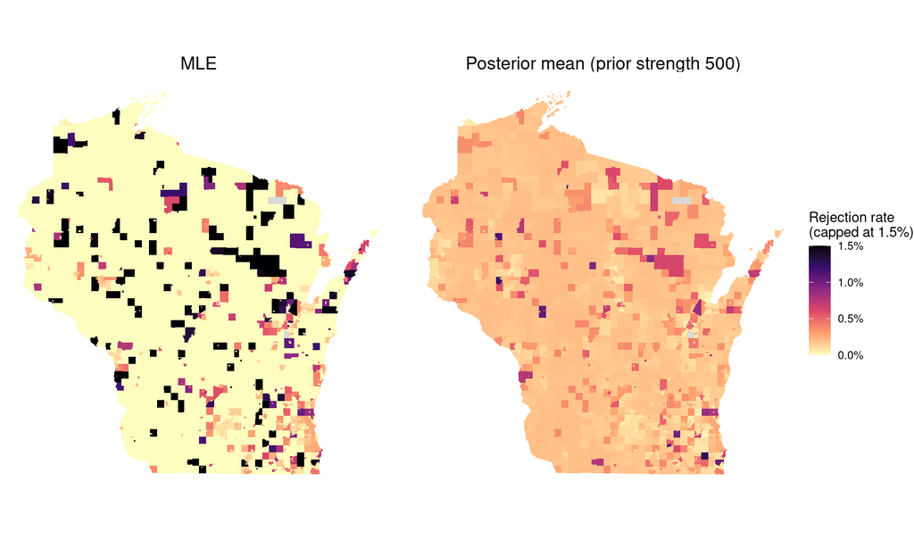

- Note that maps of shrunken estimates can mislead too - the highest *adjusted* rates end up in more populated places (Gelman and Price 1999)

## Application

- The posterior mean can be thought of as a “weighted average” of the prior mean and the MLE
  - The weights are controlled by the variance of the prior.

  $$E[\pi_i | Y_i] = \frac{Y_i + \alpha_0}{n_i + \alpha_0 + \beta_0} = \underbrace{\frac{n_i}{n_i + \alpha_0 + \beta_0}}_{\text{weight on data}} \times \frac{Y_i}{n_i} + \underbrace{\frac{\alpha_0 + \beta_0}{n_i + \alpha_0 + \beta_0}}_{\text{weight on prior}} \times \frac{\alpha_0}{\alpha_0 + \beta_0}$$
  - Can interpret the hyper-parameters for this case - $\alpha_0$ and $\beta_0$ - as the number of “previously observed” counts.
- Stronger priors $\leadsto$ narrower credible intervals
  - But it takes a *lot* more data to move the posterior distribution from the prior.
- Often, the prior serves to **regularize** our estimates
  - We want our estimates to be “pulled” towards a particular value if there’s very little data.
  - A common type of “regularizing” prior is designed to attenuate our estimates to $0$.

## Next week

- **Estimating Bayesian models**
  - Most posteriors don’t have a nice closed form
    - Beta-binomial is the classic conjugate prior.
    - Normal-Normal is also common (you’ll see a variation on this on the problem set)
  - **Markov Chain Monte Carlo** (MCMC): drawing samples from a posterior that we can only evaluate up to a proportionality constant
  - The **Metropolis-Hastings** algorithm and **Gibbs sampling**
- **Bayesian regression**
  - Putting priors on regression coefficients and the error variance
- **Introduction to Stan**
  - Write down the model – let Stan implement the MCMC sampler
- **Readings:** Chapters 3 and 9 of McElreath (2020)

## References

Gelman, Andrew, and Phillip N. Price. 1999. “All Maps of Parameter Estimates Are Misleading.” *Statistics in Medicine* 18 (23): 3221–34. https://doi.org/10.1002/(SICI)1097-0258(19991215)18:23<3221::AID-SIM312>3.0.CO;2-M.

McElreath, Richard. 2020. *Statistical Rethinking: A Bayesian Course with Examples in R and Stan*. 2nd ed. Chapman and Hall/CRC. https://xcelab.net/rm/.

Shur, Alexander. 2026. *How Inconsistent Standards Led to Dozens of Disenfranchised Voters in Mequon*. Votebeat; republished by Wisconsin Watch. https://wisconsinwatch.org/2026/07/wisconsin-election-mequon-disenfranchised-voters-absentee-ballot-envelope-witness-addresses/.

U.S. Election Assistance Commission. 2023. *Election Administration and Voting Survey 2022 (Public Release Dataset, V1)*. [Https://www.eac.gov/research-and-data/datasets-codebooks-and-surveys](https://www.eac.gov/research-and-data/datasets-codebooks-and-surveys).

U.S. Election Assistance Commission. 2025. *Election Administration and Voting Survey 2024 (Public Release Dataset, V1)*. [Https://www.eac.gov/research-and-data/datasets-codebooks-and-surveys](https://www.eac.gov/research-and-data/datasets-codebooks-and-surveys).